# Session 03 Python Data Programming

[**CCMVI2085U Machine Learning for Predictive Analytics in Business @ CBS ISUP 2020**](https://kursuskatalog.cbs.dk/2019-2020/KAN-CCMVI2085U.aspx?lang=en-GB)

Course coordinator: [Bowei Chen](https://boweichen.github.io/) | Email: bc.acc@cbs.dk

```python
%load_ext nb_black
```

In this session, we are going to study and pratice Python data programming.

# Table of Contents

## Data collection

**Data collection** is the the collection or group of data in a particular structure. Python produces a large number of useful data structures in its standard library such as list, tuple, set, and dictionary.

### Lists

Lists are the most commonly used data structure. Think of it as a sequence of data that is enclosed in square brackets and data are separated by a comma. Each of these data can be accessed by calling it's index value.

Lists are declared by just equating a variable to `[ ]` or `list`.

```python
a = []  # This is an empty list
```

```python
type(a)
```

```
list
```

One can directly assign the sequence of data to a list x as shown.

```python
x = ["apple", "orange"]
x
```

```
['apple', 'orange']
```

#### Indexing

In Python, indexing starts from 0. Thus now the list x, which has two elements will have apple at index 0 and orange at index 1.

```python
x[0]
```

```
'apple'
```

Indexing can also be done in reverse order. That is the last element can be accessed first. Here, indexing starts from -1. Thus index value -1 will be orange and index -2 will be apple.

```python
x[-1]
```

```
'orange'
```

```python
x[-2]
```

```
'apple'
```

As you might have already guessed, x[0] = x[-2], x[1] = x[-1]. This concept can be extended towards lists with more elements.

```python
y = ["carrot", "potato"]
```

Here we have declared two lists x and y, and each contains its own data. Now, these two lists can again be put into another list say z which will have it's data as two lists. This list inside a list is called as **nested lists** and is how an array would be declared which we will see later.

```python
z = [x, y]
z
```

```
[['apple', 'orange'], ['carrot', 'potato']]
```

Indexing in nested lists can be quite confusing if you do not understand how indexing works in python. So let us break it down and then arrive at a conclusion. Let us access the data 'apple' in the above nested list. First, at index 0 there is a list ['apple','orange'] and at index 1 there is another list ['carrot','potato']. Hence z[0] should give us the first list which contains 'apple'.

```python
z1 = z[0]
z1
```

```
['apple', 'orange']
```

Now observe that z1 is not at all a nested list thus to access 'apple', z1 should be indexed at 0.

```python
z1[0]
```

```
'apple'
```

Instead of doing the above, In python, you can access 'apple' by just writing the index values each time side by side.

```python
z[0][0]
```

```
'apple'
```

If there was a list inside a list inside a list then you can access the innermost value by executing `z[ ][ ][ ]`.

#### Slicing

Indexing was only limited to accessing a single element, slicing on the other hand is accessing a sequence of data inside the list. In other words "slicing" the list. In a slicing, the start position `start` and end position `stop` of the selection are written as `[start:stop]`. The range start <= x < stop is selected. **Note that the item at start is included, but the item at stop is not included.**

```python
num = [2, 4, 1, 6, 5, 6, 0, 9, 8]
num
```

```
[2, 4, 1, 6, 5, 6, 0, 9, 8]
```

```python
num[0:4]
```

```
[2, 4, 1, 6]
```

```python
num[:4]
```

```
[2, 4, 1, 6]
```

If `start` is omitted, the selection is made from the beginning, and if stop is omitted, the selection is made up to the end. If both are omitted, all items are selected.

```python
num[1:]
```

```
[4, 1, 6, 5, 6, 0, 9, 8]
```

You can also slice a parent list with a fixed length or step length.

```python
num[::2]
```

```
[2, 1, 5, 0, 8]
```

#### Built in list functions

To find the length of the list or the number of elements in a list, **len( )** is used.

```python
len(num)
```

```
9
```

If the list consists of all integer elements then **min( )** and **max( )** gives the minimum and maximum value in the list.

```python
min(num)
```

```
0
```

```python
max(num)
```

```
9
```

Lists can be **concatenated** by adding, '+' them. The resultant list will contain all the elements of the lists that were added. The resultant list will not be a nested list.

```python
[1, 2, 3] + [5, 4, 7]
```

```
[1, 2, 3, 5, 4, 7]
```

```python
x = [1, 2, 3]
x.extend([5, 4, 7])
```

```python
x
```

```
[1, 2, 3, 5, 4, 7]
```

There might arise a requirement where you might need to check if a particular element is there in a predefined list. Consider the below list.

```python
names = ["Earth", "Air", "Fire", "Water", "Apple"]
```

To check if 'Fire' and 'Rajath' is present in the list names. A conventional approach would be to use a for loop and iterate over the list and use the if condition. But in python you can use 'a in b' concept which would return 'True' if a is present in b and 'False' if not.

```python
"Fire" in names
```

```
True
```

```python
"Rajath" in names
```

```
False
```

```python
y = list()
type(y)
```

```
list
```

```python
list("hello")
```

```
['h', 'e', 'l', 'l', 'o']
```

**append( )** is used to add a element at the end of the list.

```python
lst = [1, 1, 4, 8, 7]
```

```python
lst.append(1)
print(lst)
```

```
[1, 1, 4, 8, 7, 1]
```

**count( )** is used to count the number of a particular element that is present in the list.

```python
lst.count(1)
```

```
3
```

**append( )** function can also be used to add a entire list at the end. Observe that the resultant list becomes a nested list.

```python
lst1 = [5, 4, 2, 8]
```

```python
lst.append(lst1)
print(lst)
```

```
[1, 1, 4, 8, 7, 1, [5, 4, 2, 8]]
```

But if nested list is not what is desired then **extend( )** function can be used.

```python
lst.extend(lst1)
print(lst)
```

```
[1, 1, 4, 8, 7, 1, [5, 4, 2, 8], 5, 4, 2, 8]
```

**index( )** is used to find the index value of a particular element. Note that if there are multiple elements of the same value then the first index value of that element is returned.

```python
lst.index(8)
```

```
3
```

**insert(x,y)** is used to insert a element y at a specified index value x. **append( )** function made it only possible to insert at the end.

```python
lst.insert(5, "name")
print(lst)
```

```
[1, 1, 4, 8, 7, 'name', 1, [5, 4, 2, 8], 5, 4, 2, 8]
```

**insert(x,y)** inserts but does not replace element. If you want to replace the element with another element you simply assign the value to that particular index.

```python
lst[5] = "Python"
print(lst)
```

```
[1, 1, 4, 8, 7, 'Python', 1, [5, 4, 2, 8], 5, 4, 2, 8]
```

**pop( )** function return the last element in the list. This is similar to the operation of a stack. Hence it wouldn't be wrong to tell that lists can be used as a stack.

```python
lst.pop()
```

```
8
```

```python
lst
```

```
[1, 1, 4, 8, 7, 'Python', 1, [5, 4, 2, 8], 5, 4, 2]
```

Index value can be specified to pop a ceratin element corresponding to that index value.

```python
lst.pop(0)
```

```
1
```

```python
lst
```

```
[1, 4, 8, 7, 'Python', 1, [5, 4, 2, 8], 5, 4, 2]
```

**pop( )** is used to remove element based on it's index value which can be assigned to a variable. One can also remove element by specifying the element itself using the **remove( )** function.

```python
lst.remove("Python")
print(lst)
```

```
[1, 4, 8, 7, 1, [5, 4, 2, 8], 5, 4, 2]
```

Alternative to **remove** function but with using index value is **del**

```python
del lst[1]
print(lst)
```

```
[1, 8, 7, 1, [5, 4, 2, 8], 5, 4, 2]
```

The entire elements present in the list can be reversed by using the **reverse()** function.

```python
lst.reverse()
print(lst)
```

```
[2, 4, 5, [5, 4, 2, 8], 1, 7, 8, 1]
```

Note that the nested list [5,4,2,8] is treated as a single element of the parent list lst. Thus the elements inside the nested list is not reversed.

Python offers built in operation **sort( )** to arrange the elements in ascending order.

```python
print(lst[3])
```

```
[5, 4, 2, 8]
```

```python
lst[3].sort()
print(lst)
```

```
[2, 4, 5, [2, 4, 5, 8], 1, 7, 8, 1]
```

For descending order, By default the reverse condition will be False for reverse. Hence changing it to True would arrange the elements in descending order.

```python
lst[3].sort(reverse=True)
print(lst)
```

```
[2, 4, 5, [8, 5, 4, 2], 1, 7, 8, 1]
```

#### Copying a list

Most of the new python programmers commit this mistake. Consider the following,

```python
lista = [2, 1, 4, 3]
listb = lista
print(listb)
```

```
[2, 1, 4, 3]
```

Here, We have declared a list, lista = [2,1,4,3]. This list is copied to listb by assigning it's value and it get's copied as seen. Now we perform some random operations on lista.

```python
lista.pop()
print(lista)
```

```
[2, 1, 4]
```

```python
lista.append(9)
print(lista)
```

```
[2, 1, 4, 9]
```

```python
print(listb)
```

```
[2, 1, 4, 9]
```

```python
a = 1
b = a
a = 2
print(a, b)
print(type(a), type(b))
```

```
2 1
<class 'int'> <class 'int'>
```

listb has also changed though no operation has been performed on it. This is because you have assigned the same memory space of lista to listb. So how do fix this?

If you recall, in slicing we had seen that parentlist[a:b] returns a list from parent list with start index a and end index b and if a and b is not mentioned then by default it considers the first and last element. We use the same concept here. By doing so, we are assigning the data of lista to listb as a variable.

```python
lista = [2, 1, 4, 3]
```

```python
listb = lista[:]
print(listb)
```

```
[2, 1, 4, 3]
```

```python
lista.pop()
print(lista)
lista.append(9)
print(lista)
```

```
[2, 1, 4]
[2, 1, 4, 9]
```

```python
print(listb)
```

```
[2, 1, 4, 3]
```

```python
listc = lista.copy()
lista.pop()
print(lista)
lista.append(10)
print(lista)
print(listc)
```

```
[2, 1, 4]
[2, 1, 4, 10]
[2, 1, 4, 9]
```

### Tuples

Tuples are similar to lists but only big difference is the elements inside a list can be changed but in tuple it cannot be changed. Think of tuples as something which has to be True for a particular something and cannot be True for no other values. For better understanding, Recall **divmod()** function.

```python
xyz = divmod(10, 3)
print(xyz)
print(type(xyz))
```

```
(3, 1)
<class 'tuple'>
```

Here the quotient has to be 3 and the remainder has to be 1. These values cannot be changed whatsoever when 10 is divided by 3. Hence divmod returns these values in a tuple.

To define a tuple, A variable is assigned to `paranthesis ( )` or `tuple( )`.

```python
tup = ()
tup2 = tuple()
```

If you want to directly declare a tuple it can be done by using a comma at the end of the data.

```python
27, 28, 20
```

```
(27, 28, 20)
```

27 when multiplied by 2 yields 54, But when multiplied with a tuple the data is repeated twice.

```python
2 * (27,)
```

```
(27, 27)
```

Values can be assigned while declaring a tuple. It takes a list as input and converts it into a tuple or it takes a string and converts it into a tuple.

```python
tup3 = tuple([1, 2, 3])
print(tup3)
tup4 = tuple("Hello")
print(tup4)
```

```
(1, 2, 3)
('H', 'e', 'l', 'l', 'o')
```

It follows the same indexing and slicing as Lists.

```python
print(tup3[1])
tup5 = tup4[:3]
print(tup5)
```

```
2
('H', 'e', 'l')
```

#### Mapping one tuple to another

```python
(a, b, c) = ("alpha", "beta", "gamma")
```

```python
print(a, b, c)
type(a)
```

```
alpha beta gamma
```

```
str
```

```python
d = tuple("RajathKumarMP")
print(d)
```

```
('R', 'a', 'j', 'a', 't', 'h', 'K', 'u', 'm', 'a', 'r', 'M', 'P')
```

#### Built In Tuple functions

**count()** function counts the number of specified element that is present in the tuple.

```python
d.count("a")
```

```
3
```

**index()** function returns the index of the specified element. If the elements are more than one then the index of the first element of that specified element is returned

```python
d.index("a")
```

```
1
```

### Sets

Sets are mainly used to eliminate repeated numbers in a sequence/list. It is also used to perform some standard set operations.

Sets are declared as `set()` which will initialize a empty set. Also set([sequence]) can be executed to declare a set with elements

```python
set1 = set()
print(type(set1))
```

```
<class 'set'>
```

```python
set0 = set([1, 2, 2, 3, 3, 4])
print(set0)
```

```
{1, 2, 3, 4}
```

elements 2,3 which are repeated twice are seen only once. Thus in a set each element is distinct.

#### Built-in functions

```python
set1 = set([1, 2, 3])
set2 = set([2, 3, 4, 5])
```

**union( )** function returns a set which contains all the elements of both the sets without repition.

```python
set1.union(set2)
```

```
{1, 2, 3, 4, 5}
```

**add( )** will add a particular element into the set. Note that the index of the newly added element is arbitrary and can be placed anywhere not neccessarily in the end.

```python
set1.add(0)
set1
```

```
{0, 1, 2, 3}
```

**intersection( )** function outputs a set which contains all the elements that are in both sets.

```python
set1.intersection(set2)
```

```
{2, 3}
```

**difference( )** function ouptuts a set which contains elements that are in set1 and not in set2.

```python
set1.difference(set2)
```

```
{0, 1}
```

```python
set2.difference(set1)
```

```
{4, 5}
```

**symmetric_difference( )** function ouputs a function which contains elements that are in one of the sets.

```python
set2.symmetric_difference(set1)
```

```
{0, 1, 4, 5}
```

**pop( )** is used to remove an arbitrary element in the set

```python
set1.pop()
print(set1)
```

```
{1, 2, 3}
```

```python
set1.pop()
print(set1)
```

```
{2, 3}
```

**remove( )** function deletes the specified element from the set.

```python
set1.remove(2)
print(set1)
```

```
{3}
```

### Dictionaries

Python dictionary is an unordered collection of items. Each item of a dictionary has a key/value pair.

#### Creating a dictionary

Creating a dictionary is as simple as placing items inside curly braces `{}` separated by commas. An item has a key and a corresponding value that is expressed as a pair `(key: value)`. While the values can be of any data type and can repeat, keys must be of immutable type (string, number or tuple with immutable elements) and must be unique.

```python
my_dictionary = {}  # empty dictionary
```

```python
city_population = {
    "Tokyo": 13350000,  # a key-value pair
    "Los Angeles": 18550000,
    "New York City": 8400000,
    "San Francisco": 1837442,
}
print(city_population)
print(type(city_population))
```

```
{'Tokyo': 13350000, 'Los Angeles': 18550000, 'New York City': 8400000, 'San Francisco': 1837442}
<class 'dict'>
```

#### Accessing elements from dictionary

Say you want to know the population of New York. Similarly to a list, you can use brackets to access the value, but this time with the key (instead of the index):

```python
city_population["New York City"]
```

```
8400000
```

If you use the square brackets `[]`, KeyError is raised in case a key is not found in the dictionary. On the other hand, the **get()** method returns None if the key is not found.

```python
print(city_population.get("London"))
```

```
None
```

#### Changing and adding values

Say you wanted to change the population numbers for San Francisco, because it turns out 837,442 people live there, not 1,837,442 (Maybe San Francisco actually belongs in a different dictionary called “villages”).

You can name the index of the item you want to change, using `=` to set the new population value:

```python
city_population["San Francisco"] = 837442
city_population
```

```
{'Tokyo': 13350000,
 'Los Angeles': 18550000,
 'New York City': 8400000,
 'San Francisco': 837442}
```

Let’s add another big city to the dictionary. To do this, you’ll need to assign a value to a key that doesn’t yet exist:

```python
city_population["Mumbai"] = 11980000
city_population
```

```
{'Tokyo': 13350000,
 'Los Angeles': 18550000,
 'New York City': 8400000,
 'San Francisco': 837442,
 'Mumbai': 11980000}
```

#### Removing elements

- We can remove a particular item in a dictionary by using the **pop()** method. This method removes an item with the provided key and returns the value.
- The **popitem()** method can be used to remove and return an arbitrary (key, value) item pair from the dictionary.
- All the items can be removed at once, using the **clear()** method.
- We can also use the **del keyword** to remove individual items or the entire dictionary itself.

```python
city_population.pop("Mumbai")
print(city_population)
```

```
{'Tokyo': 13350000, 'Los Angeles': 18550000, 'New York City': 8400000, 'San Francisco': 837442}
```

```python
city_population.popitem()
print(city_population)
```

```
{'Tokyo': 13350000, 'Los Angeles': 18550000, 'New York City': 8400000}
```

```python
# remove all items
city_population.clear()
print(city_population)
```

```
{}
```

```python
city_population = {
    "Tokyo": 13350000,  # a key-value pair
    "Los Angeles": 18550000,
    "New York City": 8400000,
    "San Francisco": 1837442,
}
city_population
```

```
{'Tokyo': 13350000,
 'Los Angeles': 18550000,
 'New York City': 8400000,
 'San Francisco': 1837442}
```

```python
del city_population["San Francisco"]
print(city_population)
```

```
{'Tokyo': 13350000, 'Los Angeles': 18550000, 'New York City': 8400000}
```

## Control flow

**Control flow** is the basic decision-making process in programming, which determines how a computer program will respond when given certain conditions and parameters. There are three types of control flows: **selection**, **sequence** and **iteration**.

### if, elif, else

The `if-elif-else` statement is used in Python for selection decision making.

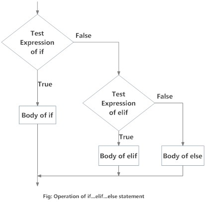

```python
statement1 = False
statement2 = True

if statement1:
    print("statement1 is True")
elif statement2:
    print("statement2 is True")
else:
    print("statement1 and statement2 are False")
```

```
statement2 is True
```

**Indentation** refers to the spaces at the beginning of a code line. Where in other programming languages the indentation in code is for readability only, the indentation in Python is very important. Python uses indentation to indicate a block of code.

**Examples:**

```python
statement1 = statement2 = True

if statement1:
    if statement2:
        print("both statement1 and statement2 are True")
```

```
both statement1 and statement2 are True
```

```python
statement1 = False

if statement1:
    print("printed if statement1 is True")
    print("still inside the if block")
```

```python
if statement1:
    print("printed if statement1 is True")

print("now outside the if block")
```

```
now outside the if block
```

### for loops

The `for loop` in Python is used to iterate over a sequence (such as list, tuple) or iteratable objects, and executes the containing block once for each element. Iterating over a sequence is also called **traversal**.

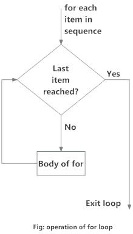

```python
for x in [1, 2, 3]:
    print(x)
```

```
1
2
3
```

Any kind of list can be used in the for loop. For example, we can use **range()** function to generate a sequence of numbers. At its simplest, it accepts an integer and returns a range object (it is an iterable object).

```python
type(range(4))
```

```
range
```

```python
for x in range(4):
    print(x)
```

```
0
1
2
3
```

Note: by default range start at 0, the stop number is not included. Therefore, **range(4)** does not include 4 !

```python
for x in range(0, 21, 5):  # the incrementation. Default is 1
    print(x)
```

```
0
5
10
15
20
```

```python
for x in range(-3, 3):
    print(x)
```

```
-3
-2
-1
0
1
2
```

```python
for word in ["scientific", "computing", "with", "python"]:
    print(word)
```

```
scientific
computing
with
python
```

To iterate over key-value pairs of a dictionary:

```python
params = {
    "parameter1": 1.0,
    "parameter2": 2.0,
    "parameter3": 3.0,
}

print(type(params))
print(params)

for key, value in params.items():
    print(key + " = " + str(value))
#     print("%s = %0.1f" % (key, value))
```

```
<class 'dict'>
{'parameter1': 1.0, 'parameter2': 2.0, 'parameter3': 3.0}
parameter1 = 1.0
parameter2 = 2.0
parameter3 = 3.0
```

Sometimes it is useful to have access to the indices of the values when iterating over a list. We can use the **enumerate()** function for this. The **enumerate()** function adds a counter as the key of the enumerate object.

```python
for idx, x in enumerate(range(-3, 3)):
    print(idx, x)
```

```
0 -3
1 -2
2 -1
3 0
4 1
5 2
```

A convenient and compact way to initialize lists:

```python
l1 = [x ** 2 for x in range(0, 5)]

print(l1)
```

```
[0, 1, 4, 9, 16]
```

The basic syntax uses square brackets.

```
[ expression for item in list if conditional ]
```

This is equivalent to:

```
for item in list:
    if conditional:
        expression
```

### while loops

The `while loop` in Python is used to iterate over a block of code as long as the test expression (condition) is true. We generally use this loop when we don't know the number of times to iterate beforehand.

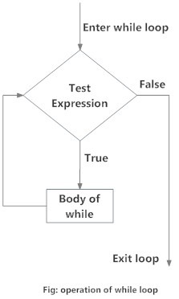

```python
i = 0
while i < 5:
    print(i)
    i = i + 1
print("done")
```

```
0
1
2
3
4
done
```

## Functions

A function in Python is defined using the keyword `def`, followed by a function name, a signature within parentheses `()`, and a colon `:`. The following code, with one additional level of indentation, is the function body.

```python
def func0():
    print("test")
```

```python
func0()
```

```
test
```

Optionally, but highly recommended, we can define a so called **docstring**, which is a description of the functions purpose and behaivor. The docstring should follow directly after the function definition, before the code in the function body.

```python
def func1(s):
    """
    Print a string 's' and tell how many characters it has
    """
    print(s + " has " + str(len(s)) + " characters")
```

```python
help(func1)
```

```
Help on function func1 in module __main__:

func1(s)
    Print a string 's' and tell how many characters it has
```

```python
func1("test")
```

```
test has 4 characters
```

Functions that returns a value use the **return** keyword:

```python
def square(x):
    """
    Return the square of x.
    """
    return x ** 2
```

```python
square(4)
```

```
16
```

We can return multiple values from a function using tuples (see above):

```python
def powers(x):
    """
    Return a few powers of x.
    """
    return x ** 2, x ** 3, x ** 4
```

```python
powers(3)
```

```
(9, 27, 81)
```

```python
x2, x3, x4 = powers(3)

print(x3)
```

```
27
```

### Default argument and keyword arguments

In a definition of a function, we can give default values to the arguments the function takes:

```python
def myfunc(x, p=2, debug=False):
    if debug:
        print("evaluating myfunc for x = " + str(x) + " using exponent p = " + str(p))
    return x ** p
```

If we don't provide a value of the `debug` argument when calling the the function `myfunc` it defaults to the value provided in the function definition:

```python
myfunc(5)
```

```
25
```

```python
myfunc(5, p=3, debug=True)
```

```
evaluating myfunc for x = 5 using exponent p = 3
```

```
125
```

**If we explicitly list the name of the arguments in the function calls, they do not need to come in the same order as in the function definition**. This is called **keyword arguments**, and is often very useful in functions that takes a lot of optional arguments.

```python
myfunc(p=3, debug=True, x=7)
```

```
evaluating myfunc for x = 7 using exponent p = 3
```

```
343
```

### Unnamed functions (lambda function)

In Python we can also create unnamed functions, using the **lambda** keyword:

```python
f1 = lambda x: x ** 2

# is equivalent to
def f2(x):
    return x ** 2
```

```python
f1(2), f2(2)
```

```
(4, 4)
```

This technique is useful for example when we want to pass a simple function as an argument to another function, like the following

```python
# map is a built-in python function
map(lambda x: x ** 2, range(-3, 4))
```

```
<map at 0x1ef407d5088>
```

The above **map()** function applies a given function to each item of an iterable (list, tuple etc.).

```python
list(map(lambda x: x ** 2, range(-3, 4)))
```

```
[9, 4, 1, 0, 1, 4, 9]
```

## Classes and modules

**As in this course we are focused on Python data programing, I am not going to further introduce how to create your own classes and modules here. You just need to know what these concepts are and how to use the them when you import libraries and initiate a machine learning model**

Python supports modular programming at different levels. A library that you import into your experiment can be simply considered as a big module written by others, you use `import` function to load it. Each library contains a number of classes. Classes are the key features of object-oriented programming (OOP). Python is an OOP language. Unlike other procedure oriented programming languages, where the main emphasis is on functions, OOP mainly uses objects to solve sophisticated problems which allows us reuse code and avoid repetitions. Simply, a class is a structure for representing an object and the operations that can be performed on the object. In Python, a class can contain **attributes** (variables) and **methods** (functions). Note that calling class methods can modify the state of that particular class instance, but does not affect other class instances or any global variables.

Let me give you an example of module and class. In the next session, we are going to use the `sklearn` library to implement a linear regression model, so we will initate an object of the class `LinearRegression` from the `sklearn` library. We can specify the attributes of the object (e.g., if we want the fitted line with bias term or not) and we can also use the class function to fit the model with the training data and predict future responses for a given test data.

## NumPy

The NumPy package (module) is used in almost all numerical computation in Python. It is a package that provides high-performance vector, matrix and higher-dimensional data structures for Python. It is implemented in C and Fortran so when calculations are vectorized (formulated with vectors and matrices), performance is very good.

The NumPy package in Python is referred by `numpy`. To use it, you need to import the module:

```python
import numpy as np
```

Once you can check the version:

```python
np.__version__
```

```
'1.16.5'
```

### Creating NumPy arrays

There are a number of ways to initialize new Numpy arrays, for example from

- converting from Python lists or tuples
- using functions that are dedicated to generating numpy arrays, such as `arange`, `linspace`, etc.
- reading data from files

#### From lists

For example, to create new vector and matrix arrays from Python lists we can use the `numpy.array` function

```python
# a vector: the argument to the array function is a Python list
v = np.array([1, 2, 3, 4])
v
```

```
array([1, 2, 3, 4])
```

```python
# a matrix: the argument to the array function is a nested Python list
M = np.array([[1, 2], [3, 4]])
M
```

```
array([[1, 2],
       [3, 4]])
```

The `v` and `M` objects are both of the type `ndarray` that the `numpy` module provides.

```python
type(v), type(M)
```

```
(numpy.ndarray, numpy.ndarray)
```

The difference between the `v` and `M` arrays is only their shapes. We can get information about the shape of an array by using the `ndarray.shape` property.

```python
v.shape
```

```
(4,)
```

```python
M.shape
```

```
(2, 2)
```

The number of elements in the array is available through the `ndarray.size` property:

```python
M.size
```

```
4
```

Equivalently, we could use the function `numpy.shape` and `numpy.size`:

```python
np.shape(M)
```

```
(2, 2)
```

```python
np.size(M)
```

```
4
```

So far the `numpy.ndarray` looks a lot like a Python list (or nested list). Why not simply use Python lists for computations instead of creating a new array type?

There are several reasons:

- Python lists are very general. They can contain any kind of object. They are **dynamically typed**. They do not support mathematical functions such as matrix and dot multiplications, etc. Implementating such functions for Python lists would not be very efficient because of the dynamic typing.
- Numpy arrays are **statically typed** and **homogeneous**. The type of the elements is determined when array is created.
- Numpy arrays are memory efficient and fast implementation of mathematical functions such as multiplication and addition of `numpy` arrays can be implemented.

Using the `dtype` (data type) property of an `ndarray`, we can see what type the data of an array has:

```python
M.dtype
```

```
dtype('int32')
```

```python
print(M)
```

```
[[1 2]
 [3 4]]
```

```python
M[0, 0] = 5
print(M)
```

```
[[5 2]
 [3 4]]
```

If we want, we can explicitly define the type of the array data when we create it, using the `dtype` keyword argument:

```python
N = np.array([[1, 2], [3, 4]], dtype=complex)
N
```

```
array([[1.+0.j, 2.+0.j],
       [3.+0.j, 4.+0.j]])
```

Common types that can be used with `dtype` are: `int`, `float`, `complex`, `bool`, and `object` (string).

#### Using array-generating functions

For larger arrays it is inpractical to initialize the data manually, we can use one of the many functions in `numpy` that generates arrays of different forms. Some of the more common are:

```python
# create a range (the end value is not included)
x = np.arange(-1, 1, 0.1)  # arguments: start, stop, step
print(x)
print(type(x))
```

```
[-1.00000000e+00 -9.00000000e-01 -8.00000000e-01 -7.00000000e-01
 -6.00000000e-01 -5.00000000e-01 -4.00000000e-01 -3.00000000e-01
 -2.00000000e-01 -1.00000000e-01 -2.22044605e-16  1.00000000e-01
  2.00000000e-01  3.00000000e-01  4.00000000e-01  5.00000000e-01
  6.00000000e-01  7.00000000e-01  8.00000000e-01  9.00000000e-01]
<class 'numpy.ndarray'>
```

```python
x.dtype  # dtype is determined automatically unless specified
```

```
dtype('float64')
```

```python
y = np.arange(0, 10, 1)  # range of integers
y
```

```
array([0, 1, 2, 3, 4, 5, 6, 7, 8, 9])
```

```python
y.dtype
```

```
dtype('int32')
```

```python
z = np.arange(0, 10, 1, dtype=float)  # specifying dtype as float
z
```

```
array([0., 1., 2., 3., 4., 5., 6., 7., 8., 9.])
```

NumPy arrays contain values of a single type, so it is important to have some knowledge of those types and their limitations. Because NumPy is built in C, the types will be familiar to users of C, Fortran, and other related languages. The standard NumPy data types are listed in the following table. Note that when constructing an array, they can be specified using a string:

```
np.zeros(10, dtype='int16')
```

Or using the associated NumPy object:

```
np.zeros(10, dtype=np.int16)
```

| Data type | Description |
| --- | --- |
| `bool_` | Boolean (True or False) stored as a byte |
| `int_` | Default integer type (same as C `long`; normally either `int64` or `int32`) |
| `intc` | Identical to C `int` (normally `int32` or `int64`) |
| `intp` | Integer used for indexing (same as C `ssize_t`; normally either `int32` or `int64`) |
| `int8` | Byte (-128 to 127) |
| `int16` | Integer (-32768 to 32767) |
| `int32` | Integer (-2147483648 to 2147483647) |
| `int64` | Integer (-9223372036854775808 to 9223372036854775807) |
| `uint8` | Unsigned integer (0 to 255) |
| `uint16` | Unsigned integer (0 to 65535) |
| `uint32` | Unsigned integer (0 to 4294967295) |
| `uint64` | Unsigned integer (0 to 18446744073709551615) |
| `float_` | Shorthand for `float64`. |
| `float16` | Half precision float: sign bit, 5 bits exponent, 10 bits mantissa |
| `float32` | Single precision float: sign bit, 8 bits exponent, 23 bits mantissa |
| `float64` | Double precision float: sign bit, 11 bits exponent, 52 bits mantissa |
| `complex_` | Shorthand for `complex128`. |
| `complex64` | Complex number, represented by two 32-bit floats |
| `complex128` | Complex number, represented by two 64-bit floats |

```python
z.dtype
```

```
dtype('float64')
```

```python
# using linspace, both end points ARE included
np.linspace(0, 10, 11)  # arguments: start, stop, N
```

```
array([ 0.,  1.,  2.,  3.,  4.,  5.,  6.,  7.,  8.,  9., 10.])
```

```python
# uniform random numbers in interval [0,1]
np.random.rand(5, 5)
```

```
array([[0.42839756, 0.84561524, 0.98443694, 0.80675007, 0.59320014],
       [0.92844614, 0.28061592, 0.45456949, 0.50877417, 0.2412209 ],
       [0.65674814, 0.67515996, 0.34004178, 0.9879127 , 0.50146124],
       [0.28383046, 0.30482182, 0.26839046, 0.22999273, 0.1928793 ],
       [0.13108572, 0.03158603, 0.99825692, 0.26718275, 0.54085856]])
```

```python
# standard normal distributed random numbers
np.random.randn(5, 5)
```

```
array([[-1.3884601 , -1.37623641,  1.6214713 ,  0.88651202,  1.14535524],
       [ 1.19665263, -3.03144875,  0.52004707,  0.25270119,  0.65309644],
       [-1.29193793, -0.36058792,  1.03450792, -0.97017187,  0.75792319],
       [ 0.99443135,  0.80584793,  1.70570217, -0.27551408, -1.01454816],
       [ 0.54208697,  0.49700384, -0.68981386,  0.05347953, -1.58482464]])
```

```python
# diagonal matrix
np.diag([1, 2, 3])
```

```
array([[1, 0, 0],
       [0, 2, 0],
       [0, 0, 3]])
```

```python
# zeros
np.zeros((3, 3))
```

```
array([[0., 0., 0.],
       [0., 0., 0.],
       [0., 0., 0.]])
```

```python
# ones
np.ones((3, 3))
```

```
array([[1., 1., 1.],
       [1., 1., 1.],
       [1., 1., 1.]])
```

```python
# ones as int
np.ones((3, 3), dtype=int)
```

```
array([[1, 1, 1],
       [1, 1, 1],
       [1, 1, 1]])
```

```python
# three-dimensional
np.ones((3, 3, 3))
```

```
array([[[1., 1., 1.],
        [1., 1., 1.],
        [1., 1., 1.]],

       [[1., 1., 1.],
        [1., 1., 1.],
        [1., 1., 1.]],

       [[1., 1., 1.],
        [1., 1., 1.],
        [1., 1., 1.]]])
```

### Indexing

We can index elements in an array using the square bracket and indices:

```python
# v is a vector, and has only one dimension, taking one index
v[0]
```

```
1
```

```python
# M is a matrix, or a 2 dimensional array, taking two indices
print(M)
M[1, 1]
```

```
[[5 2]
 [3 4]]
```

```
4
```

```python
# If we omit an index of a multidimensional array it returns the whole row (or, in general, a N-1 dimensional array)
M[1]
```

```
array([3, 4])
```

```python
M[1, :]
```

```
array([3, 4])
```

The same thing can be achieved with using `:` instead of an index:

```python
M[1, :]  # row 1
```

```
array([3, 4])
```

```python
M[:, 1]  # column 1
```

```
array([2, 4])
```

We can assign new values to elements in an array using indexing:

```python
M[0, 0] = -1
M
```

```
array([[-1,  2],
       [ 3,  4]])
```

```python
M[:, 0] = 3
M
```

```
array([[3, 2],
       [3, 4]])
```

#### Index slicing

Index slicing is the technical name for the syntax `M[lower:upper:step]` to extract part of an array:

```python
A = np.array([1, 2, 3, 4, 5])
A
```

```
array([1, 2, 3, 4, 5])
```

```python
A[1:3]
```

```
array([2, 3])
```

```python
A[1:3] = [-2, -3]
A
```

```
array([ 1, -2, -3,  4,  5])
```

We can omit any of the three parameters in `M[lower:upper:step]`:

```python
A[::]  # lower, upper, step all take the default values
```

```
array([ 1, -2, -3,  4,  5])
```

```python
A[::2]  # step is 2, lower and upper defaults to the beginning and end of the array
```

```
array([ 1, -3,  5])
```

```python
A[:3]  # first three elements
```

```
array([ 1, -2, -3])
```

```python
A[3:]  # elements from index 3
```

```
array([4, 5])
```

Negative indices counts from the end of the array (positive index from the begining):

```python
A = np.array([1, 2, 3, 4, 5])
```

```python
A[-1]  # the last element in the array
```

```
5
```

```python
A[-3:]  # the last three elements
```

```
array([3, 4, 5])
```

```python
A = np.array([[n + m * 10 for n in range(5)] for m in range(5)])
print(A)
```

```
[[ 0  1  2  3  4]
 [10 11 12 13 14]
 [20 21 22 23 24]
 [30 31 32 33 34]
 [40 41 42 43 44]]
```

```python
C = A
C[1,] = 0
print(C)
print(A)
```

```
[[ 0  1  2  3  4]
 [ 0  0  0  0  0]
 [20 21 22 23 24]
 [30 31 32 33 34]
 [40 41 42 43 44]]
[[ 0  1  2  3  4]
 [ 0  0  0  0  0]
 [20 21 22 23 24]
 [30 31 32 33 34]
 [40 41 42 43 44]]
```

```python
C2 = A.copy()
C2[2,] = 0
print(C2)
print(A)
```

```
[[ 0  1  2  3  4]
 [ 0  0  0  0  0]
 [ 0  0  0  0  0]
 [30 31 32 33 34]
 [40 41 42 43 44]]
[[ 0  1  2  3  4]
 [ 0  0  0  0  0]
 [20 21 22 23 24]
 [30 31 32 33 34]
 [40 41 42 43 44]]
```

```python
# a block from the original array
A[1:4, 1:4]
```

```
array([[ 0,  0,  0],
       [21, 22, 23],
       [31, 32, 33]])
```

#### Fancy indexing

Fancy indexing is the name for when an array or list is used in-place of an index:

```python
A
```

```
array([[ 0,  1,  2,  3,  4],
       [ 0,  0,  0,  0,  0],
       [20, 21, 22, 23, 24],
       [30, 31, 32, 33, 34],
       [40, 41, 42, 43, 44]])
```

```python
row_indices = [1, 2, 3]
print(A[row_indices])
```

```
[[ 0  0  0  0  0]
 [20 21 22 23 24]
 [30 31 32 33 34]]
```

```python
col_indices = [1, 2, 3]
A[row_indices, col_indices]
```

```
array([ 0, 22, 33])
```

```python
# equivalent to
A[1, 1], A[2, 2], A[3, 3]
```

```
(0, 22, 33)
```

We can also index **masks**: If the index mask is an NumPy array of with data type `bool`, then an element is selected (True) or not (False) depending on the value of the index mask at the position each element:

```python
B = np.array([n for n in range(5)])
B
```

```
array([0, 1, 2, 3, 4])
```

```python
row_mask = np.array([True, False, True, False, False])
B[row_mask]
```

```
array([0, 2])
```

```python
# same thing
row_mask = np.array([1, 0, 1, 0, 0], dtype=bool)
print(row_mask)
B[row_mask]
```

```
[ True False  True False False]
```

```
array([0, 2])
```

This feature is very useful to conditionally select elements from an array, using for example comparison operators:

```python
x = np.arange(0, 10, 0.5)
x
```

```
array([0. , 0.5, 1. , 1.5, 2. , 2.5, 3. , 3.5, 4. , 4.5, 5. , 5.5, 6. ,
       6.5, 7. , 7.5, 8. , 8.5, 9. , 9.5])
```

```python
# want values of x that are at least 5 and have no decimal component
mask = (x >= 5) & (x % 1 == 0)
mask
```

```
array([False, False, False, False, False, False, False, False, False,
       False,  True, False,  True, False,  True, False,  True, False,
        True, False])
```

```python
x[mask]
```

```
array([5., 6., 7., 8., 9.])
```

## Pandas

`pandas` is a library written for the Python for data manipulation and analysis. In particular, it offers data structures and operations for manipulating numerical tables and time series.

**Library features**

- DataFrame object for data manipulation with integrated indexing
- Tools for reading and writing data between in-memory data structures and different file formats
- Data alignment and integrated handling of missing data
- Reshaping and pivoting of data sets
- Label-based slicing, fancy indexing, and subsetting of large data sets
- Data structure column insertion and deletion
- Group-by engine allowing split-apply-combine operations on data sets
- Data set merging and joining
- Hierarchical axis indexing to work with high-dimensional data in a lower-dimensional data structure
- Time series-functionality: date range generation and frequency conversion, moving window statistics, moving window linear regressions, date shifting and lagging

The library is highly optimized for performance, with critical code paths written in Cython or C.

### Read data from CSV

Download `Airline_Passenger_Satisfaction.csv` from our CBS OneDrive folder and read it into your created notebook

```python
import pandas as pd
```

```python
df = pd.read_csv("data/Airline_Passenger_Satisfaction.csv", header=0, engine="python")
df
```

|  | id | Gender | Customer Type | Age | Type of Travel | Class | Flight Distance | Inflight wifi service | Departure/Arrival time convenient | Ease of Online booking | ... | Inflight entertainment | On-board service | Leg room service | Baggage handling | Checkin service | Inflight service | Cleanliness | Departure Delay in Minutes | Arrival Delay in Minutes | satisfaction |
| --- | --- | --- | --- | --- | --- | --- | --- | --- | --- | --- | --- | --- | --- | --- | --- | --- | --- | --- | --- | --- | --- |
| 0 | 70172 | Male | Loyal Customer | 13 | Personal Travel | Eco Plus | 460 | 3 | 4 | 3 | ... | 5 | 4 | 3 | 4 | 4 | 5 | 5 | 25 | 18.0 | neutral or dissatisfied |
| 1 | 5047 | Male | disloyal Customer | 25 | Business travel | Business | 235 | 3 | 2 | 3 | ... | 1 | 1 | 5 | 3 | 1 | 4 | 1 | 1 | 6.0 | neutral or dissatisfied |
| 2 | 110028 | Female | Loyal Customer | 26 | Business travel | Business | 1142 | 2 | 2 | 2 | ... | 5 | 4 | 3 | 4 | 4 | 4 | 5 | 0 | 0.0 | satisfied |
| 3 | 24026 | Female | Loyal Customer | 25 | Business travel | Business | 562 | 2 | 5 | 5 | ... | 2 | 2 | 5 | 3 | 1 | 4 | 2 | 11 | 9.0 | neutral or dissatisfied |
| 4 | 119299 | Male | Loyal Customer | 61 | Business travel | Business | 214 | 3 | 3 | 3 | ... | 3 | 3 | 4 | 4 | 3 | 3 | 3 | 0 | 0.0 | satisfied |
| ... | ... | ... | ... | ... | ... | ... | ... | ... | ... | ... | ... | ... | ... | ... | ... | ... | ... | ... | ... | ... | ... |
| 103899 | 94171 | Female | disloyal Customer | 23 | Business travel | Eco | 192 | 2 | 1 | 2 | ... | 2 | 3 | 1 | 4 | 2 | 3 | 2 | 3 | 0.0 | neutral or dissatisfied |
| 103900 | 73097 | Male | Loyal Customer | 49 | Business travel | Business | 2347 | 4 | 4 | 4 | ... | 5 | 5 | 5 | 5 | 5 | 5 | 4 | 0 | 0.0 | satisfied |
| 103901 | 68825 | Male | disloyal Customer | 30 | Business travel | Business | 1995 | 1 | 1 | 1 | ... | 4 | 3 | 2 | 4 | 5 | 5 | 4 | 7 | 14.0 | neutral or dissatisfied |
| 103902 | 54173 | Female | disloyal Customer | 22 | Business travel | Eco | 1000 | 1 | 1 | 1 | ... | 1 | 4 | 5 | 1 | 5 | 4 | 1 | 0 | 0.0 | neutral or dissatisfied |
| 103903 | 62567 | Male | Loyal Customer | 27 | Business travel | Business | 1723 | 1 | 3 | 3 | ... | 1 | 1 | 1 | 4 | 4 | 3 | 1 | 0 | 0.0 | neutral or dissatisfied |

103904 rows × 24 columns

In the above code, we have a parameter **engine="python"**. Usually, we don't need to add this argument but sometimes the file contains some symbols which 'c' engine does not support so we need to specify python engine.

```python
type(df)
```

```
pandas.core.frame.DataFrame
```

Check the dimension of the dataset

```python
df.shape
```

```
(103904, 24)
```

Show the first 5 rows of the imported dataset by using **head()**

```python
df.head()
```

|  | id | Gender | Customer Type | Age | Type of Travel | Class | Flight Distance | Inflight wifi service | Departure/Arrival time convenient | Ease of Online booking | ... | Inflight entertainment | On-board service | Leg room service | Baggage handling | Checkin service | Inflight service | Cleanliness | Departure Delay in Minutes | Arrival Delay in Minutes | satisfaction |
| --- | --- | --- | --- | --- | --- | --- | --- | --- | --- | --- | --- | --- | --- | --- | --- | --- | --- | --- | --- | --- | --- |
| 0 | 70172 | Male | Loyal Customer | 13 | Personal Travel | Eco Plus | 460 | 3 | 4 | 3 | ... | 5 | 4 | 3 | 4 | 4 | 5 | 5 | 25 | 18.0 | neutral or dissatisfied |
| 1 | 5047 | Male | disloyal Customer | 25 | Business travel | Business | 235 | 3 | 2 | 3 | ... | 1 | 1 | 5 | 3 | 1 | 4 | 1 | 1 | 6.0 | neutral or dissatisfied |
| 2 | 110028 | Female | Loyal Customer | 26 | Business travel | Business | 1142 | 2 | 2 | 2 | ... | 5 | 4 | 3 | 4 | 4 | 4 | 5 | 0 | 0.0 | satisfied |
| 3 | 24026 | Female | Loyal Customer | 25 | Business travel | Business | 562 | 2 | 5 | 5 | ... | 2 | 2 | 5 | 3 | 1 | 4 | 2 | 11 | 9.0 | neutral or dissatisfied |
| 4 | 119299 | Male | Loyal Customer | 61 | Business travel | Business | 214 | 3 | 3 | 3 | ... | 3 | 3 | 4 | 4 | 3 | 3 | 3 | 0 | 0.0 | satisfied |

5 rows × 24 columns

Get variable names

```python
df.columns
```

```
Index(['id', 'Gender', 'Customer Type', 'Age', 'Type of Travel', 'Class',
       'Flight Distance', 'Inflight wifi service',
       'Departure/Arrival time convenient', 'Ease of Online booking',
       'Gate location', 'Food and drink', 'Online boarding', 'Seat comfort',
       'Inflight entertainment', 'On-board service', 'Leg room service',
       'Baggage handling', 'Checkin service', 'Inflight service',
       'Cleanliness', 'Departure Delay in Minutes', 'Arrival Delay in Minutes',
       'satisfaction'],
      dtype='object')
```

Check variable types

```python
df.dtypes
```

```
id                                     int64
Gender                                object
Customer Type                         object
Age                                    int64
Type of Travel                        object
Class                                 object
Flight Distance                        int64
Inflight wifi service                  int64
Departure/Arrival time convenient      int64
Ease of Online booking                 int64
Gate location                          int64
Food and drink                         int64
Online boarding                        int64
Seat comfort                           int64
Inflight entertainment                 int64
On-board service                       int64
Leg room service                       int64
Baggage handling                       int64
Checkin service                        int64
Inflight service                       int64
Cleanliness                            int64
Departure Delay in Minutes             int64
Arrival Delay in Minutes             float64
satisfaction                          object
dtype: object
```

Summarise the numerical variables in your imported dataset using **describe()**

```python
df.describe()
```

|  | id | Age | Flight Distance | Inflight wifi service | Departure/Arrival time convenient | Ease of Online booking | Gate location | Food and drink | Online boarding | Seat comfort | Inflight entertainment | On-board service | Leg room service | Baggage handling | Checkin service | Inflight service | Cleanliness | Departure Delay in Minutes | Arrival Delay in Minutes |
| --- | --- | --- | --- | --- | --- | --- | --- | --- | --- | --- | --- | --- | --- | --- | --- | --- | --- | --- | --- |
| count | 103904.000000 | 103904.000000 | 103904.000000 | 103904.000000 | 103904.000000 | 103904.000000 | 103904.000000 | 103904.000000 | 103904.000000 | 103904.000000 | 103904.000000 | 103904.000000 | 103904.000000 | 103904.000000 | 103904.000000 | 103904.000000 | 103904.000000 | 103904.000000 | 103594.000000 |
| mean | 64924.210502 | 39.379706 | 1189.448375 | 2.729683 | 3.060296 | 2.756901 | 2.976883 | 3.202129 | 3.250375 | 3.439396 | 3.358158 | 3.382363 | 3.351055 | 3.631833 | 3.304290 | 3.640428 | 3.286351 | 14.815618 | 15.178678 |
| std | 37463.812252 | 15.114964 | 997.147281 | 1.327829 | 1.525075 | 1.398929 | 1.277621 | 1.329533 | 1.349509 | 1.319088 | 1.332991 | 1.288354 | 1.315605 | 1.180903 | 1.265396 | 1.175663 | 1.312273 | 38.230901 | 38.698682 |
| min | 1.000000 | 7.000000 | 31.000000 | 0.000000 | 0.000000 | 0.000000 | 0.000000 | 0.000000 | 0.000000 | 0.000000 | 0.000000 | 0.000000 | 0.000000 | 1.000000 | 0.000000 | 0.000000 | 0.000000 | 0.000000 | 0.000000 |
| 25% | 32533.750000 | 27.000000 | 414.000000 | 2.000000 | 2.000000 | 2.000000 | 2.000000 | 2.000000 | 2.000000 | 2.000000 | 2.000000 | 2.000000 | 2.000000 | 3.000000 | 3.000000 | 3.000000 | 2.000000 | 0.000000 | 0.000000 |
| 50% | 64856.500000 | 40.000000 | 843.000000 | 3.000000 | 3.000000 | 3.000000 | 3.000000 | 3.000000 | 3.000000 | 4.000000 | 4.000000 | 4.000000 | 4.000000 | 4.000000 | 3.000000 | 4.000000 | 3.000000 | 0.000000 | 0.000000 |
| 75% | 97368.250000 | 51.000000 | 1743.000000 | 4.000000 | 4.000000 | 4.000000 | 4.000000 | 4.000000 | 4.000000 | 5.000000 | 4.000000 | 4.000000 | 4.000000 | 5.000000 | 4.000000 | 5.000000 | 4.000000 | 12.000000 | 13.000000 |
| max | 129880.000000 | 85.000000 | 4983.000000 | 5.000000 | 5.000000 | 5.000000 | 5.000000 | 5.000000 | 5.000000 | 5.000000 | 5.000000 | 5.000000 | 5.000000 | 5.000000 | 5.000000 | 5.000000 | 5.000000 | 1592.000000 | 1584.000000 |

### Indexing in pandas

There are two ways to index a Pandas DataFrame.

- `loc` works on labels in the index.
- `iloc` works on the positions in the index (so it only takes integers).

```python
df.loc[0]
```

```
id                                                     70172
Gender                                                  Male
Customer Type                                 Loyal Customer
Age                                                       13
Type of Travel                               Personal Travel
Class                                               Eco Plus
Flight Distance                                          460
Inflight wifi service                                      3
Departure/Arrival time convenient                          4
Ease of Online booking                                     3
Gate location                                              1
Food and drink                                             5
Online boarding                                            3
Seat comfort                                               5
Inflight entertainment                                     5
On-board service                                           4
Leg room service                                           3
Baggage handling                                           4
Checkin service                                            4
Inflight service                                           5
Cleanliness                                                5
Departure Delay in Minutes                                25
Arrival Delay in Minutes                                  18
satisfaction                         neutral or dissatisfied
Name: 0, dtype: object
```

```python
df.iloc[0]
```

```
id                                                     70172
Gender                                                  Male
Customer Type                                 Loyal Customer
Age                                                       13
Type of Travel                               Personal Travel
Class                                               Eco Plus
Flight Distance                                          460
Inflight wifi service                                      3
Departure/Arrival time convenient                          4
Ease of Online booking                                     3
Gate location                                              1
Food and drink                                             5
Online boarding                                            3
Seat comfort                                               5
Inflight entertainment                                     5
On-board service                                           4
Leg room service                                           3
Baggage handling                                           4
Checkin service                                            4
Inflight service                                           5
Cleanliness                                                5
Departure Delay in Minutes                                25
Arrival Delay in Minutes                                  18
satisfaction                         neutral or dissatisfied
Name: 0, dtype: object
```

Check if the column `id` is unique.

```python
df["id"].is_unique
```

```
True
```

Set the column `id` as the index

```python
df.set_index("id", inplace=True)
```

```python
df.head()
```

| id | Gender | Customer Type | Age | Type of Travel | Class | Flight Distance | Inflight wifi service | Departure/Arrival time convenient | Ease of Online booking | Gate location | ... | Inflight entertainment | On-board service | Leg room service | Baggage handling | Checkin service | Inflight service | Cleanliness | Departure Delay in Minutes | Arrival Delay in Minutes | satisfaction |
| --- | --- | --- | --- | --- | --- | --- | --- | --- | --- | --- | --- | --- | --- | --- | --- | --- | --- | --- | --- | --- | --- |
| 70172 | Male | Loyal Customer | 13 | Personal Travel | Eco Plus | 460 | 3 | 4 | 3 | 1 | ... | 5 | 4 | 3 | 4 | 4 | 5 | 5 | 25 | 18.0 | neutral or dissatisfied |
| 5047 | Male | disloyal Customer | 25 | Business travel | Business | 235 | 3 | 2 | 3 | 3 | ... | 1 | 1 | 5 | 3 | 1 | 4 | 1 | 1 | 6.0 | neutral or dissatisfied |
| 110028 | Female | Loyal Customer | 26 | Business travel | Business | 1142 | 2 | 2 | 2 | 2 | ... | 5 | 4 | 3 | 4 | 4 | 4 | 5 | 0 | 0.0 | satisfied |
| 24026 | Female | Loyal Customer | 25 | Business travel | Business | 562 | 2 | 5 | 5 | 5 | ... | 2 | 2 | 5 | 3 | 1 | 4 | 2 | 11 | 9.0 | neutral or dissatisfied |
| 119299 | Male | Loyal Customer | 61 | Business travel | Business | 214 | 3 | 3 | 3 | 3 | ... | 3 | 3 | 4 | 4 | 3 | 3 | 3 | 0 | 0.0 | satisfied |

5 rows × 23 columns

```python
df.loc[70172]
```

```
Gender                                                  Male
Customer Type                                 Loyal Customer
Age                                                       13
Type of Travel                               Personal Travel
Class                                               Eco Plus
Flight Distance                                          460
Inflight wifi service                                      3
Departure/Arrival time convenient                          4
Ease of Online booking                                     3
Gate location                                              1
Food and drink                                             5
Online boarding                                            3
Seat comfort                                               5
Inflight entertainment                                     5
On-board service                                           4
Leg room service                                           3
Baggage handling                                           4
Checkin service                                            4
Inflight service                                           5
Cleanliness                                                5
Departure Delay in Minutes                                25
Arrival Delay in Minutes                                  18
satisfaction                         neutral or dissatisfied
Name: 70172, dtype: object
```

```python
df.iloc[0]
```

```
Gender                                                  Male
Customer Type                                 Loyal Customer
Age                                                       13
Type of Travel                               Personal Travel
Class                                               Eco Plus
Flight Distance                                          460
Inflight wifi service                                      3
Departure/Arrival time convenient                          4
Ease of Online booking                                     3
Gate location                                              1
Food and drink                                             5
Online boarding                                            3
Seat comfort                                               5
Inflight entertainment                                     5
On-board service                                           4
Leg room service                                           3
Baggage handling                                           4
Checkin service                                            4
Inflight service                                           5
Cleanliness                                                5
Departure Delay in Minutes                                25
Arrival Delay in Minutes                                  18
satisfaction                         neutral or dissatisfied
Name: 70172, dtype: object
```

## References

The material of this session is created mainly based on the following open resources:

- https://github.com/rajathkmp/Python-Lectures
- https://github.com/cuttlefishh/python-for-data-analysis/tree/master/lessons
- https://github.com/jakevdp/PythonDataScienceHandbook
- https://github.com/jrjohansson/scientific-python-lectures

In addition, the following book can be a good material for your directed study offline (and it is in our CBS OneDrive shared folder)

[figure not shown]